# Practice Activity Week 5

# Data

`secret_map.csv` contains a secret code for each county in the U.S. In this Practice Activity, you will figure out the code and then create a map in `ggplot` showing what you found.

```r
secret_map <- read.csv("secret_map.csv")
```

# Simple Map of US Counties

Let’s start by just creating a map of all of the counties in the continuous US.

1. Use the `counties()` function from the **tigris** package to load a dataframe of US **counties** with their polygon files. Save this dataframe into an object named `county_map`.

```r
county_map <- counties()
```

2. Using `ggplot()`, generate a map of the US counties. Have the fill color for each county be white and the outline color be a dark grey. Use cartesian coordinates. *Hint: `geom_sf()` and `coord_sf()` will be helpful here!*

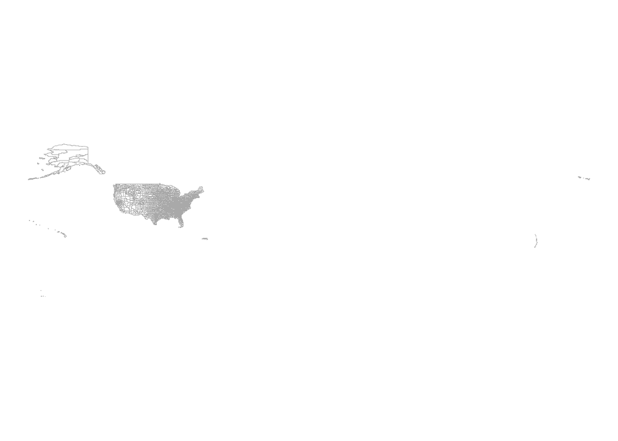

```r
ggplot(county_map) +
  geom_sf(fill = "white", color = "darkgray") +
  coord_sf()+
  theme_void()
```

3. Remove all axes labels and gridlines. *Hint: There is a built-in theme that can do this!*
4. While cartesian coordinates are typical, they are actually somewhat visually misleading since the globe is a sphere. A recommended system for showing the US is the “Albers Equal Area Conic Projection”. Copy and paste your code from Questions 2 and 3 and change the coordinate system to this projection (or any conic projection). *Hint: Check out the documentation for `coord_sf()` for other projection systems.*

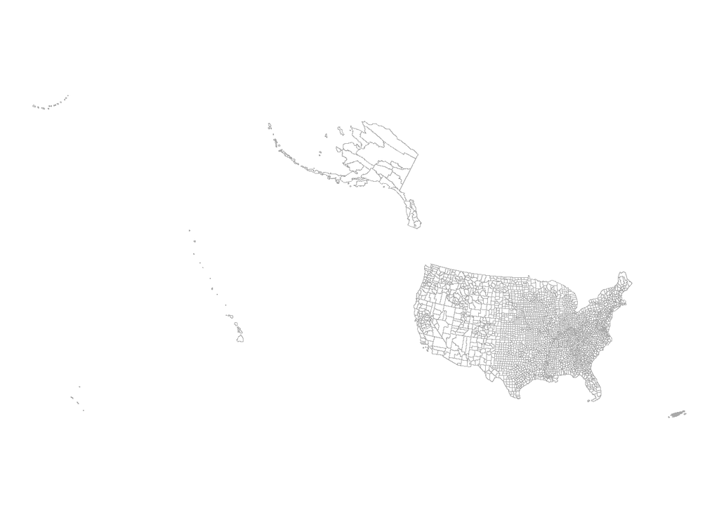

```r
ggplot(county_map) +
  geom_sf(fill = "white", color = "darkgray") +
  coord_sf(crs = 5070)+
  theme_void()
```

Great! Now you should have a nice simple map of all of the US counties. Let’s add the information from the `secret_map.csv` data.

# Color that Map

To color the map we will need to join the `county_map` dataframe with the `secret_map` dataframe. We will break this up into a few steps since there are some adjustments we need to make to each dataset before we join them together!

5. There are a couple of typos in the `secret_code` column of the `secret_map` data. Let’s fix these errors!
1. Any “g” should be replaced with “F” (case matters!)
2. The secret code should start with the hashtag character (#)

```r
secret_map <- secret_map |>
  mutate(secret_code = str_replace_all(secret_code,
                                       "g", "F"),
         secret_code = str_c("#", secret_code))
```

6. Currently, the `county_map` dataframe doesn’t have the names of the states, only their state code. Use the `fips_codes` object from the **tigris** package to add the state names into the `county_map` dataframe. *Hint 1: You may want to join a dataframe smaller than the original `fips_codes`!* *Hint 2: Pay attention to the column names between the two datasets!*

```r
View(county_map)
View(fips_codes)
StateNames <- fips_codes %>%
  select(state, state_code, state_name, county) %>%
  distinct()

county_map <- county_map %>%
  inner_join(StateNames, by = c("STATEFP" = "state_code", "NAMELSAD" = "county"))
```

7. Add the `secret_code` information to the `county_map` dataframe. *Hint: Pay attention to the column names between the two datasets!*

```r
county_map <- county_map %>%
  left_join(secret_map, by = c("state_name" = "state", "NAME" = "county"))
```

8. Remove the counties with missing values in the `secret_code` column.

```r
county_map <- county_map %>%
  filter(!is.na(secret_code))
```

9. It turns out that the secret code gives you the colors that should be used in your final map. Save a **vector** called `map_colors` with the unique values of the `secret_code` column. *Hint: There should be 3 colors.*

```r
map_colors <- unique(county_map$secret_code)
```

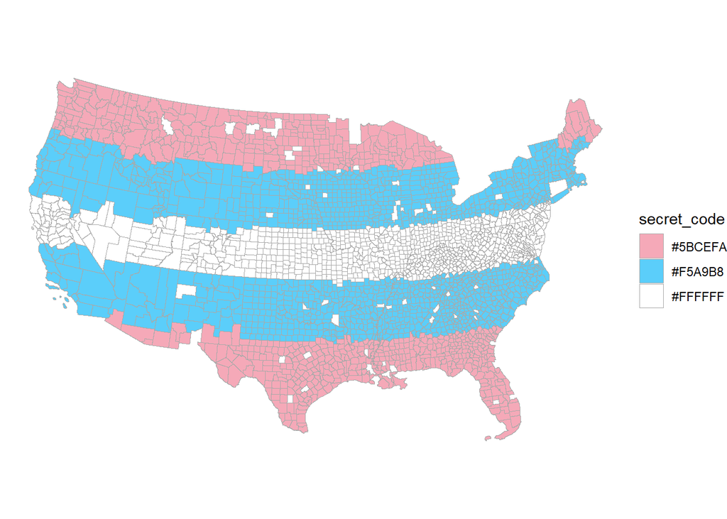

```r
ggplot(data = county_map) +
  geom_sf(aes(fill = secret_code), color = "darkgrey") +
  scale_fill_manual(values = map_colors) +
  coord_sf(crs = 5070) +
  theme_void()
```

# Canvas Submission:

> Submit a screenshot of your final plot. What flag is shown?